# Data Axle - Businesses in Sharswood

URBS 4000: Urban Studies Thesis

Author

Jed Chew

Published

October 21, 2025

## Project Title: Mixed by Design

### *A Case Study of the Philadelphia Housing Authority’s (PHA) Choice Neighborhoods Redevelopment of Sharswood*

For my Urban Studies thesis, I am researching the PHA’s Choice Neighborhoods redevelopment of the Sharswood neighborhood in North Philadelphia. I have two main research questions about the process and outcome of this redevelopment:

(1) the **process** by which the PHA aligned the politics, finance, and design for the redevelopment of Sharswood; and

(2) the early redevelopment **outcomes** relative to the Choice Neighborhoods Initiative (CNI) vision of mixed-partners, mixed-use, and mixed-income

## Part 1: Raw Data from Data Axle

**Data Axle Reference Solutions** (formerly ReferenceUSA and Infogroup) is a big data, analytics, and marketing services provider that delivers best in class data-driven, customer-centric technology solutions. It offers two main types of data:

- **Residential Historic Data:** Analyze community growth and general population differences.
- **Historic Business Data:** Analyze market trends, economic growth, or specific industries. Access categories including Company Name, Geocodes, SIC/NAICS codes, Census Tracts.

I retrieved my raw data files from Data Axle through Penn Libraries and Wharton Research and Data Services (WRDS) on October 15, 2025. The interface of Data Axle is shown below.

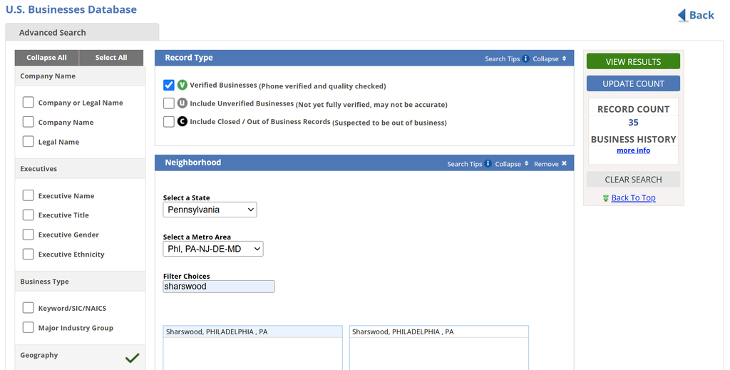

### Record Types

- **Verified Records:** have been verified by DataAxle staff through various compilation processes including phone validation
- **Unverified Records:** separate database from verified records because of one of the following three reasons:
  - records appear within data sources but have yet to be fully verified
  - partial information is contained in the record, but not all data elements are present to be considered ‘verified’ at the point of data retrieval
  - addresses are unverified (e.g. a business may have moved)

### Step 1: Load Raw Data as csv files

- DataAxle’s U.S. Businesses Data Dictionary
- Verified Businesses in Sharswood Neighborhood
- Unverified Businesses in Sharswood Neighborhood
- Philadelphia census tracts and neighborhood boundaries

```r
# Load Data Axle Data
datadict <- read_csv("data/Data_Dict.csv")
head(datadict)
```

```
# A tibble: 6 × 2
  `Field Name`         `Field Description`
  <chr>                <chr>
1 Company Name         Name of Company or Professional Name
2 Executive First Name First Name of Contact
3 Executive Last Name  Last Name of Contact
4 Address              Location address of the company
5 City                 Location city address of the company
6 State                Location state address of the company
```

```r
verified <- read_csv("data/Sharswood_Verified_Biz.csv")
verified
```

```
# A tibble: 35 × 18
   `Company Name`           `Legal Name` Address Latitude Longitude Neighborhood
   <chr>                    <chr>        <chr>   <chr>        <dbl> <chr>
 1 ATM                      <NA>         2101 S… 039.972…     -75.2 Sharswood
 2 ATM                      <NA>         2438 W… 039.975…     -75.2 Sharswood
 3 Big Picture Philadelphia <NA>         2300 W… 039.976…     -75.2 Sharswood
 4 Brothers Corner          BROTHER GRO… 2012 R… 039.975…     -75.2 Sharswood
 5 Citizens For Kenneth Wa… <NA>         2101 S… 039.972…     -75.2 Sharswood
 6 College Girard           <NA>         2101 N… 039.975…     -75.2 Sharswood
 7 El Tlaloc                <NA>         2108 R… 039.978…     -75.2 Sharswood
 8 Georgiegs Truck          <NA>         1261 N… 039.974…     -75.2 Sharswood
 9 Girard College Devmnt F… <NA>         2101 S… 039.973…     -75.2 Sharswood
10 Girard College Foundati… GIRARD COLL… 2101 S… 039.973…     -75.2 Sharswood
# ℹ 25 more rows
# ℹ 12 more variables: `Census Block Group` <dbl>, `ZIP Code` <dbl>,
#   `Company Description` <chr>, `Primary SIC Code` <chr>,
#   `Primary SIC Description` <chr>, `Primary NAICS` <dbl>,
#   `Primary NAICS Description` <chr>, `Years In Database` <dbl>,
#   `Location Type` <chr>, `Location Employee Size Range` <chr>,
#   `Square Footage` <chr>, `Record Type` <chr>
```

```r
unverified1 <- read_csv("data/Sharswood_Unverified_Biz_Pg1to10.csv")
unverified1
```

```
# A tibble: 250 × 18
   `Company Name`     Address `ZIP Code` `Legal Name` `Record Type` Neighborhood
   <chr>              <chr>        <dbl> <chr>        <chr>         <chr>
 1 100 Black Men Of … 2300 W…      19121 <NA>         Unverified    Sharswood
 2 1220 Lindley Aven… 2101 N…      19121 1220 LINDLE… Unverified    Sharswood
 3 1496 Bushwick LLC  2101 N…      19121 1496 BUSHWI… Unverified    Sharswood
 4 1518 Loudon LLC    2026 R…      19121 1518 LOUDON… Unverified    Sharswood
 5 1530 Ridge LLC     2026 R…      19121 1530 RIDGE … Unverified    Sharswood
 6 16th Associates L… 2101 N…      19121 16TH ASSOCI… Unverified    Sharswood
 7 1985 LLC           2026 R…      19121 1985 LLC     Unverified    Sharswood
 8 2048 St Inc        2048 R…      19121 2048 ST INC  Unverified    Sharswood
 9 2111 Seybert LLC   2111 W…      19121 2111 SEYBER… Unverified    Sharswood
10 2245 W Thompson S… 2245 W…      19121 2245 W THOM… Unverified    Sharswood
# ℹ 240 more rows
# ℹ 12 more variables: `Census Block Group` <dbl>, `Company Description` <lgl>,
#   `Primary SIC Code` <chr>, `Primary SIC Description` <chr>,
#   `Primary NAICS` <dbl>, `Primary NAICS Description` <chr>,
#   `Location Employee Size Range` <chr>, `Location Type` <chr>,
#   `Years In Database` <dbl>, `Square Footage` <chr>, Latitude <chr>,
#   Longitude <dbl>
```

```r
unverified2 <- read_csv("data/Sharswood_Unverified_Biz_Pg11to17.csv")
unverified2
```

```
# A tibble: 171 × 18
   `Company Name`     Address `ZIP Code` `Legal Name` `Record Type` Neighborhood
   <chr>              <chr>        <dbl> <chr>        <chr>         <chr>
 1 Miller Rothlein    2101 S…      19121 <NA>         Unverified    Sharswood
 2 Milley Meals LLC   2405 W…      19121 MILLEY MEAL… Unverified    Sharswood
 3 Miracle Revival D… 2072 R…      19121 <NA>         Unverified    Sharswood
 4 Miro Dance Theatre 2101 S…      19121 <NA>         Unverified    Sharswood
 5 Modern Konvention… 2111 W…      19121 MODERN KONV… Unverified    Sharswood
 6 Molly's World LLC  2105 W…      19121 MOLLY'S WOR… Unverified    Sharswood
 7 Moore Treats 4 U … 2300 W…      19121 MOORE TREAT… Unverified    Sharswood
 8 Motef Co           2216 W…      19121 MOTEF CO     Unverified    Sharswood
 9 MPL Corp           2101 S…      19121 MPL CORP     Unverified    Sharswood
10 Mt Calvary Aposto… 2450 W…      19121 <NA>         Unverified    Sharswood
# ℹ 161 more rows
# ℹ 12 more variables: `Census Block Group` <dbl>, `Company Description` <chr>,
#   `Primary SIC Code` <chr>, `Primary SIC Description` <chr>,
#   `Primary NAICS` <dbl>, `Primary NAICS Description` <chr>,
#   `Location Employee Size Range` <chr>, `Location Type` <chr>,
#   `Years In Database` <dbl>, `Square Footage` <chr>, Latitude <chr>,
#   Longitude <dbl>
```

```r
unverified_combined <- bind_rows(unverified1, unverified2)
write_csv(unverified_combined, "data/Sharswood_Unverified_Biz_Combined.csv")
```

```r
# rename column headings
verified <- verified |> clean_names()
unverified_combined <- unverified_combined |> clean_names()

# filter out small businesses with irrelevant SIC Codes
drop_SIC <- c("Atm-Automated Teller Machines", "Schools", "Churches", "Nonclassified Establishments", "Real Estate Management", "Townhouses", "Mailing & Shipping Kiosks")

verified_clean <- verified |>
  filter(!primary_sic_description %in% drop_SIC) |>
  select(company_name, address, latitude, longitude, census_block_group, primary_sic_code, primary_sic_description, primary_naics, primary_naics_description,
         years_in_database, location_type, location_employee_size_range, square_footage, record_type)
verified_clean
```

```
# A tibble: 19 × 14
   company_name   address latitude longitude census_block_group primary_sic_code
   <chr>          <chr>   <chr>        <dbl>              <dbl> <chr>
 1 Brothers Corn… 2012 R… 039.975…     -75.2                  2 541105
 2 El Tlaloc      2108 R… 039.978…     -75.2                  2 581212
 3 Girard Colleg… 2101 S… 039.973…     -75.2                  3 839998
 4 Girard Colleg… 2101 S… 039.973…     -75.2                  3 873303
 5 Girard Colleg… 2101 S… 039.973…     -75.2                  3 823109
 6 Greater Dane   2305 W… 039.975…     -75.2                  2 421304
 7 Johnsons Conc… 2229 W… 039.975…     -75.2                  2 869912
 8 Lev Baruch Fo… 2207 W… 039.974…     -75.2                  2 873303
 9 Lorenzo's      1301 N… 039.975…     -75.2                  2 724101
10 Mighty Writers 2300 W… 039.976…     -75.2                  2 821108
11 Miller Memori… 1518 N… 039.978…     -75.2                  1 839998
12 Moss-Gail, De… 2300 W… 039.976…     -75.2                  2 804907
13 Pham, Amber    2245 W… 039.975…     -75.2                  2 832282
14 Philly Homes … 2445 H… 039.977…     -75.2                  1 653118
15 Real Roots Fo… 2245 W… 039.975…     -75.2                  2 018198
16 RMST Delivery… 2429 S… 039.977…     -75.2                  1 421212
17 Vincen Bevera… 2048 R… 039.976…     -75.2                  2 518101
18 Woods Carpent… 2026 R… 039.976…     -75.2                  2 175102
19 Young Men Bec… 1450 N… 039.977…     -75.2                  2 839998
# ℹ 8 more variables: primary_sic_description <chr>, primary_naics <dbl>,
#   primary_naics_description <chr>, years_in_database <dbl>,
#   location_type <chr>, location_employee_size_range <chr>,
#   square_footage <chr>, record_type <chr>
```

```r
unverified_clean <- unverified_combined |>
  filter(!primary_sic_description %in% drop_SIC) |>
  select(company_name, address, latitude, longitude, census_block_group, primary_sic_code, primary_sic_description, primary_naics, primary_naics_description,
         years_in_database, location_type, location_employee_size_range, square_footage, record_type)
unverified_clean
```

```
# A tibble: 170 × 14
   company_name   address latitude longitude census_block_group primary_sic_code
   <chr>          <chr>   <chr>        <dbl>              <dbl> <chr>
 1 1518 Loudon L… 2026 R… 039.976…     -75.2                  2 653118
 2 2048 St Inc    2048 R… 039.976…     -75.2                  2 653118
 3 4545 Uber LLC  2026 R… 039.976…     -75.2                  2 653118
 4 4th Quarter C… 2438 W… 039.975…     -75.2                  2 152144
 5 Adam Analysis… 2111 W… 039.976…     -75.2                  2 865101
 6 Agricultural … 2130 W… 039.975…     -75.2                  2 013901
 7 Ah Cornerston… 2331 N… 039.974…     -75.2                  2 621111
 8 All Team Staf… 2203 W… 039.977…     -75.2                  1 736103
 9 American Acad… 2019 W… 039.977…     -75.2                  2 801101
10 Armstrong & M… 2317 W… 039.975…     -75.2                  2 873204
# ℹ 160 more rows
# ℹ 8 more variables: primary_sic_description <chr>, primary_naics <dbl>,
#   primary_naics_description <chr>, years_in_database <dbl>,
#   location_type <chr>, location_employee_size_range <chr>,
#   square_footage <chr>, record_type <chr>
```

```r
# Load spatial data
census_tracts <- tracts(state = "PA", county = "Philadelphia", year = 2020, class = "sf", cb = TRUE, progress = FALSE)
block_grps <- block_groups(state = "PA", county = "Philadelphia", year = 2020, class = "sf",cb = TRUE, progress = FALSE)

# Standardize CRS
```

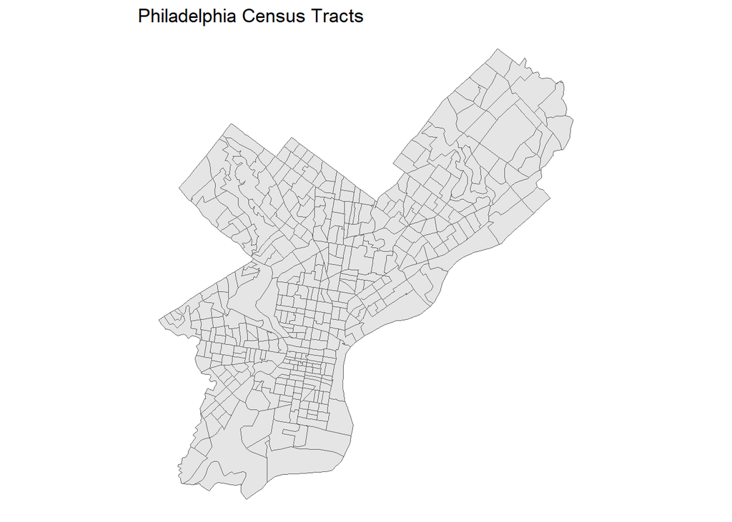

```r
# Check that all data loaded correctly
ggplot(census_tracts) +
  geom_sf() +
  labs(title = "Philadelphia Census Tracts") +
  theme_void()
```

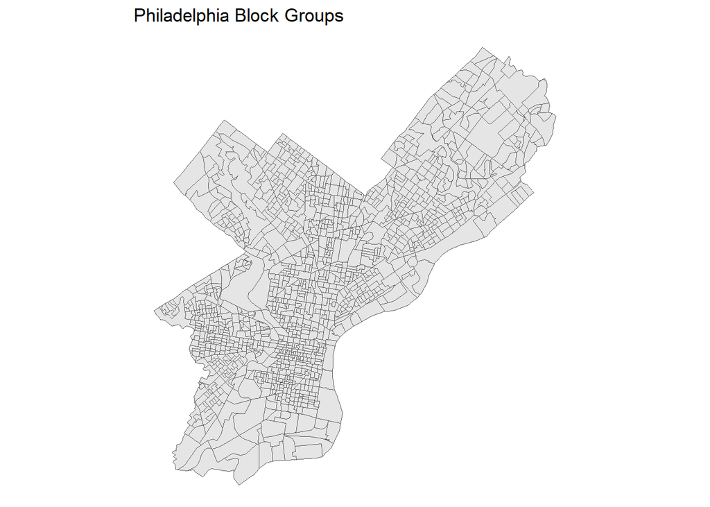

```r
ggplot(block_grps) +
  geom_sf() +
  labs(title = "Philadelphia Block Groups") +
  theme_void()
```

### Step 2: Get Philadelphia Demographic Data using `tidycensus`

```r
# Load all available variables for ACS 5-year 2022
acs_vars_2022 <- load_variables(2022, "acs5", cache = TRUE)
```

```r
# Helper Variables for Summing Population Values for Children aged 5-19
child_pop = c("B01001_004", "B01001_005", "B01001_006", "B01001_007",
                "B01001_028", "B01001_029", "B01001_030", "B01001_031")


# Helper Variable for Summing Population Values for Elderly Population
elderly_pop = c("B01001_020", "B01001_021", "B01001_022", "B01001_023",
                "B01001_024", "B01001_025",
                "B01001_044", "B01001_045", "B01001_046",
                "B01001_047", "B01001_048", "B01001_049")

# Get tract-level demographic data from 2022 ACS 5-Yr Estimates for Philadelphia
phl_tract_data <- get_acs(
  geography = "tract",
  variables = c(
    total_pop = "B01003_001",
    child_pop = child_pop,
    elderly_pop = elderly_pop,
    median_income = "B19013_001",
    poverty = "B17001_001",
    White     = "B03002_003",
    Black     = "B03002_004",
    Hispanic  = "B03002_012"
  ),
  state = "PA",
  county = "Philadelphia",
  year = 2022,
  survey = "acs5",
  output = "wide",
  geometry = TRUE
)

# Clean the county names to remove state name and "County"
phl_tract_clean <- phl_tract_data |>
  separate(
    NAME,
    into = c("tract_name", "county_name", "state_name"),
    sep = "; "
  ) |>
  mutate(
    tract_name = str_remove(tract_name, "Census Tract "),
    county_name = str_remove(county_name, " County")
  )

phl_tract_summary <- phl_tract_clean |>
  mutate(
    elderly_popE = rowSums(across(matches("^elderly_pop\\d+E$")), na.rm = TRUE),
    # for MOE, ACS guidance is to combine by quadrature
    elderly_popM = sqrt(rowSums(across(matches("^elderly_pop\\d+M$"))^2, na.rm =
                                  TRUE)),
    pct_elderly = round((elderly_popE / total_popE) *100, 2),
    child_popE = rowSums(across(matches("^child_pop\\d+E$")), na.rm = TRUE),
    child_popM = sqrt(rowSums(across(matches("^child_pop\\d+M$"))^2, na.rm =
                                  TRUE)),
    pct_child = round((child_popE/total_popE) * 100, 2),
  ) |>
  select(GEOID, tract_name, county_name, total_popE, median_incomeE, elderly_popE,
         elderly_popM, pct_elderly, child_popE, child_popM, pct_child)
```

### Step 3: Make Data Axle dataset Spatial

```r
# Convert Data Axle dataset to sf object
verified.sf <- verified_clean |>
  st_as_sf(coords = c("longitude", "latitude"), crs = 4326) |> # WGS 84
  st_transform(2272) # PA State Plane (in US Survey Feet)

unverified.sf <- unverified_clean |>
  st_as_sf(coords = c("longitude", "latitude"), crs = 4326) |>
  st_transform(2272)
```

**Join Data Axle Shapefiles to Philadelphia Census Tracts and Block Groups**

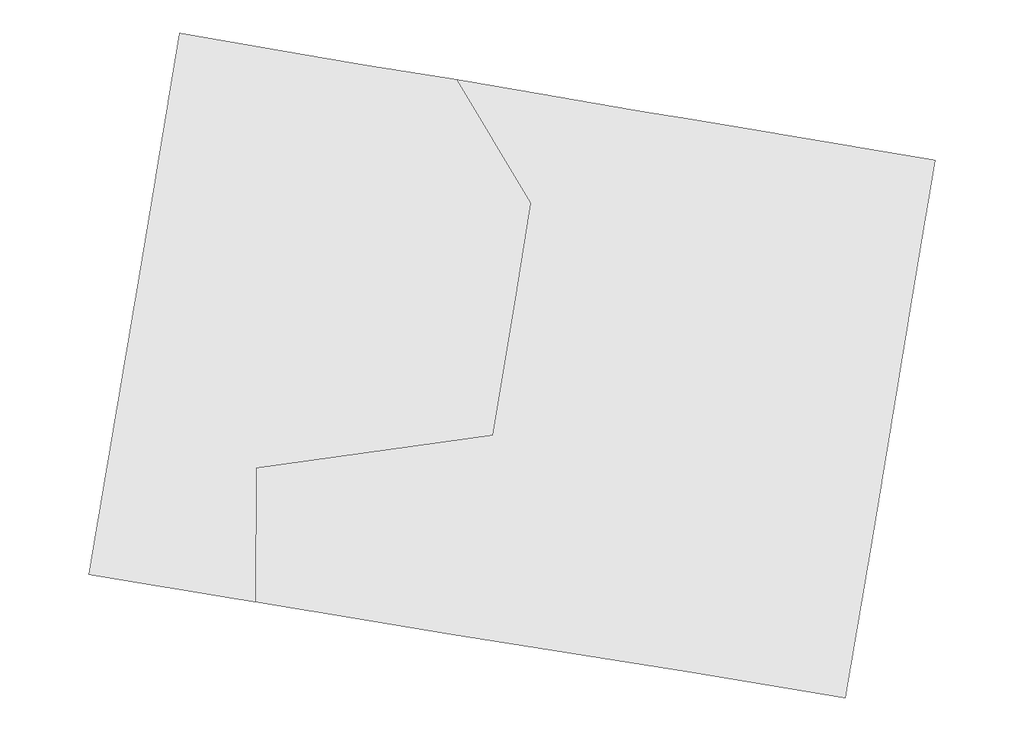

```r
# Filter Census Tracts for Sharswood
sharswood_tract_sf <- phl_tract_summary |>
  filter(tract_name == c("138", "139"))

ggplot(sharswood_tract_sf) +
  geom_sf() +
  theme_void()
```

```r
sharswood_tract <- sharswood_tract_sf |>
  st_drop_geometry()
sharswood_tract
```

```
        GEOID tract_name  county_name total_popE median_incomeE elderly_popE
1 42101013800        138 Philadelphia       2077          68864          126
2 42101013900        139 Philadelphia       2585          41042          391
  elderly_popM pct_elderly child_popE child_popM pct_child
1     78.56208        6.07        255   127.1102     12.28
2    142.44999       15.13        421   255.5876     16.29
```

```r
# Create CSV File
write_csv(sharswood_tract, "data/Sharswood_Tracts.csv")
```

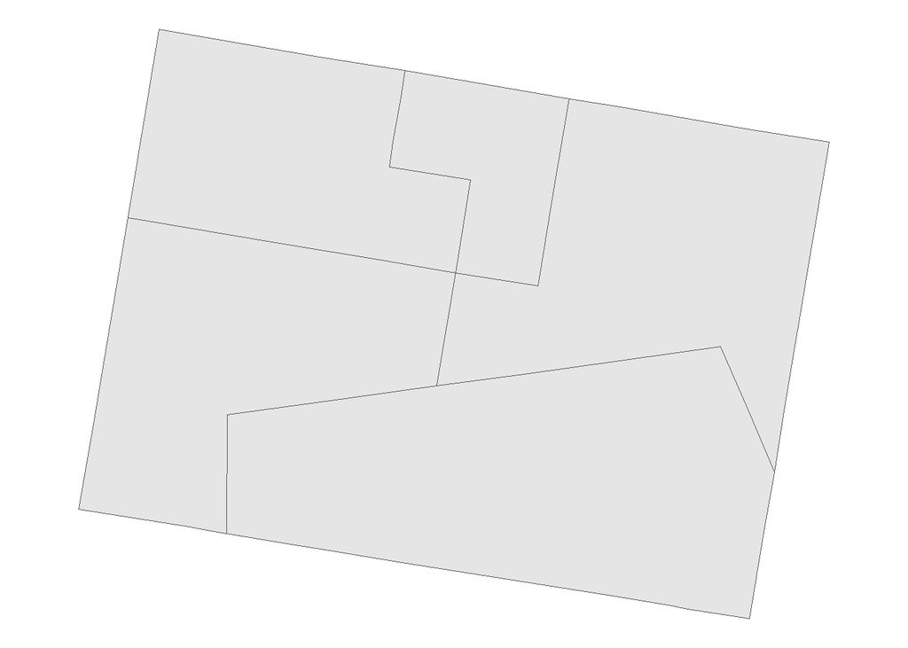

```r
# Filter Block Groups for Sharswood
ids <- c("421010138001","421010138002","421010139001",
         "421010139002","421010139003")

sharswood_bg_sf <- block_grps |>
 filter(GEOID %in% ids)

ggplot(sharswood_bg_sf) +
  geom_sf() +
  theme_void()
```

```r
sharswood_bg <- sharswood_bg_sf |>
  st_drop_geometry()
sharswood_bg
```

```
  STATEFP COUNTYFP TRACTCE BLKGRPCE              AFFGEOID        GEOID NAME
1      42      101  013900        2 1500000US421010139002 421010139002    2
2      42      101  013800        1 1500000US421010138001 421010138001    1
3      42      101  013900        3 1500000US421010139003 421010139003    3
4      42      101  013900        1 1500000US421010139001 421010139001    1
5      42      101  013800        2 1500000US421010138002 421010138002    2
       NAMELSAD LSAD  ALAND AWATER
1 Block Group 2   BG 209077      0
2 Block Group 1   BG 151595      0
3 Block Group 3   BG 288073      0
4 Block Group 1   BG  65787      0
5 Block Group 2   BG 189662      0
```

```r
# Create CSV File
write_csv(sharswood_bg, "data/Sharswood_Block_Grps.csv")
```

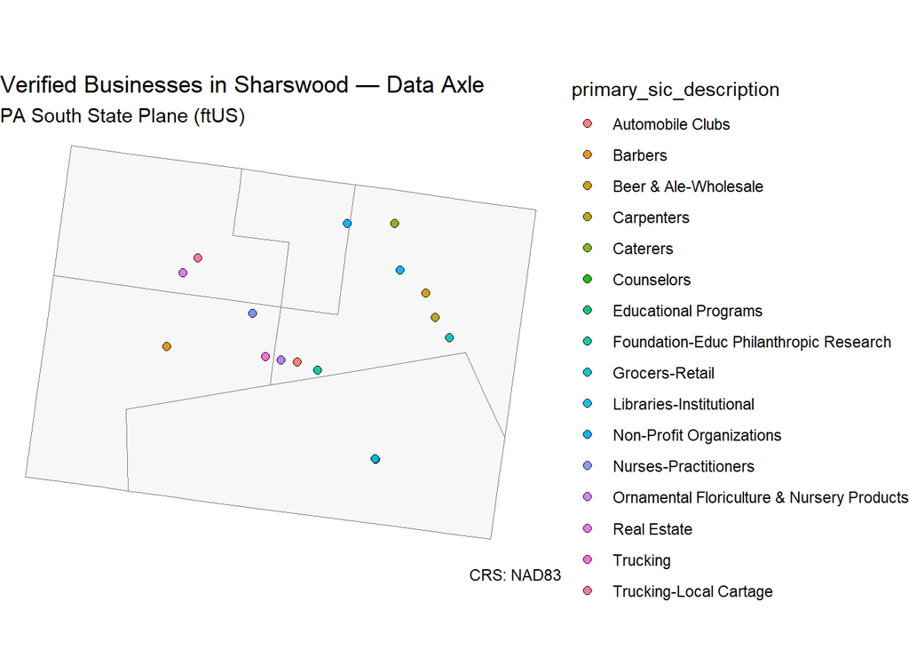

```r
# Join Shapefiles and Plot Map
sharswood_bg_sf <- st_transform(sharswood_bg_sf, st_crs(verified.sf))

ggplot() +
  geom_sf(data = sharswood_bg_sf, fill = "gray97", color = "gray50", linewidth = 0.3) +
  geom_sf(data = verified.sf, aes(fill = primary_sic_description), shape = 21, size = 2, alpha = 0.9) +
  labs(
    title = "Verified Businesses in Sharswood — Data Axle",
    subtitle = "PA South State Plane (ftUS)",
    caption = paste0("CRS: ", st_crs(block_grps)$input %||% st_crs(block_grps)$epsg)
  ) +
  theme_void()
```

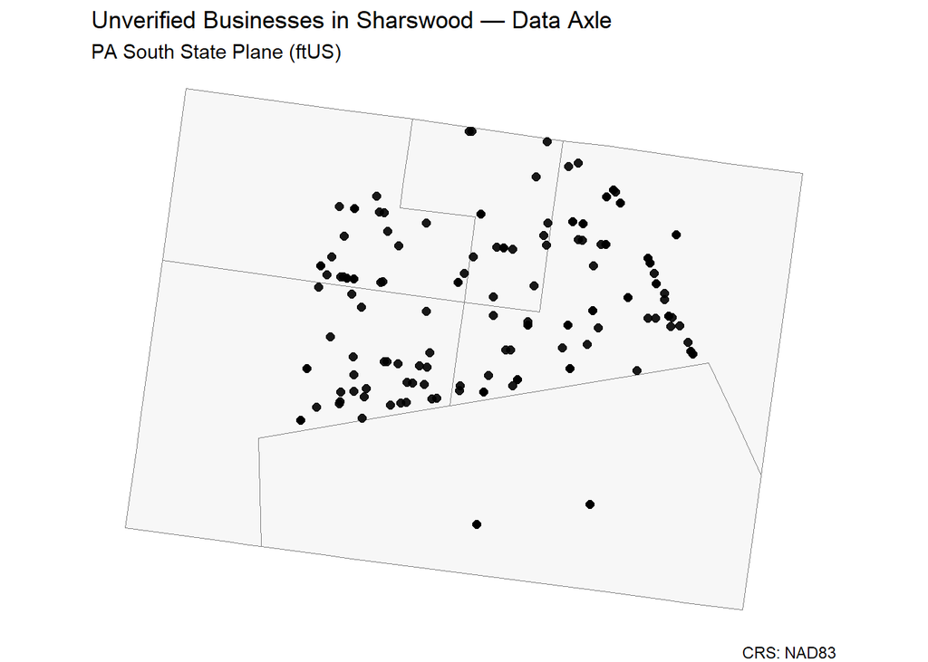

```r
ggplot() +
  geom_sf(data = sharswood_bg_sf, fill = "gray97", color = "gray50", linewidth = 0.3) +
  geom_sf(data = unverified.sf, shape = 21, size = 2, fill = "black", alpha = 0.9) +
  labs(
    title = "Unverified Businesses in Sharswood — Data Axle",
    subtitle = "PA South State Plane (ftUS)",
    caption = paste0("CRS: ", st_crs(block_grps)$input %||% st_crs(block_grps)$epsg)
  ) +
  theme_void()
```

### Step 4: Map Businesses to Property Parcels and Affordable Housing Projects

- Data Source: Department of Records Property Parcels
- Date Downloaded: Oct 19, 2025
- Link: https://opendataphilly.org/datasets/department-of-records-property-parcels/

```r
# Code to Filter out Sharswood Parcels from Philadelphia Records
# Code not Executed because Philadelphia Records File exceeds 100 MB
prop_parcels <- st_read("data/DOR_Parcel.geojson") |>
  st_transform(st_crs(sharswood_bg_sf))

sharswood_prop_parcels <- st_filter(prop_parcels, sharswood_bg_sf, .predicate = st_intersects)
```

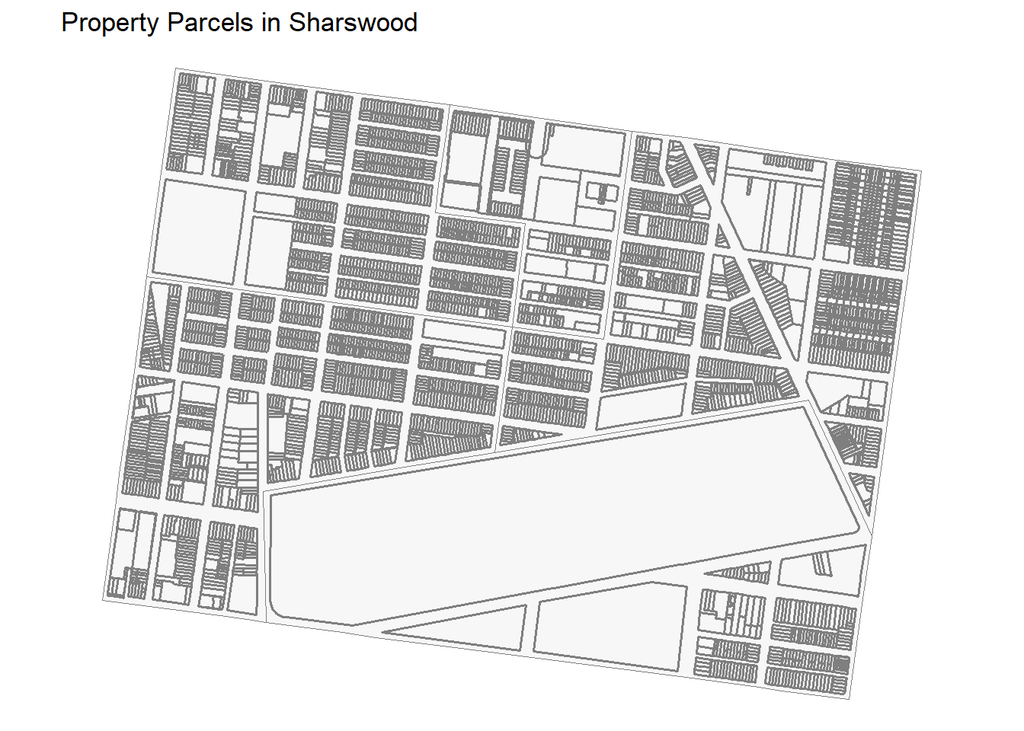

```r
sharswood_parcels <- st_read("data/sharswood_parcels.geojson")
ggplot() +
  geom_sf(data = sharswood_bg_sf, fill = "gray97", color = "gray50", linewidth = 0.3) +
  geom_sf(data = sharswood_parcels, fill = NA, color = "gray50", linewidth = 0.6) +
  labs(title = "Property Parcels in Sharswood") +
  theme_void()
```

- Data Source: Division of Housing and Community Development (DHCD)
- Date Downloaded: Oct 19, 2025
- Link: https://opendataphilly.org/datasets/affordable-housing-production/

```r
affordable_housing_parcels <- st_read("data/Affordable_housing.geojson") |>
  st_transform(st_crs(sharswood_bg_sf))
```

```
replacing null geometries with empty geometries
Simple feature collection with 484 features and 12 fields (with 22 geometries empty)
Geometry type: POINT
Dimension:     XY
Bounding box:  xmin: -75.2489 ymin: 39.90183 xmax: -74.9829 ymax: 40.12171
Geodetic CRS:  WGS 84
```

```r
sharswood_affordable <- st_filter(affordable_housing_parcels, sharswood_bg_sf,
                                  .predicate = st_within)

sharswood_affordable |>
  st_drop_geometry()
```

```
  objectid fiscal_year_complete                  project_name
1       22                   NA Harlan and Sharswood Pres Dev
2      121                 2011           Cecil B Moore III-3
3      172                 2007           Cecil B Moore III-1
4      216                 2004                     Homestart
5      345                   NA           Sharswood Phase III
6      358                 2024             Sharswood Phase 2
7      361                 2023             Sharswood Phase I
8      367                 2022          HELP Philadelphia VI
9      419                 2007                  Sharswood II
               developer_name              address     project_type total_units
1       Michaels Organization    2100 SHARSWOOD ST           Rental         113
2                    HERB CDC       1900 HARLAN ST    Homeownership          33
3                    HERB CDC       1501 N UBER ST    Homeownership          64
4                        PHDC      2618 SEYBERT ST    Homeownership           4
```

[output cut: 25 more lines]

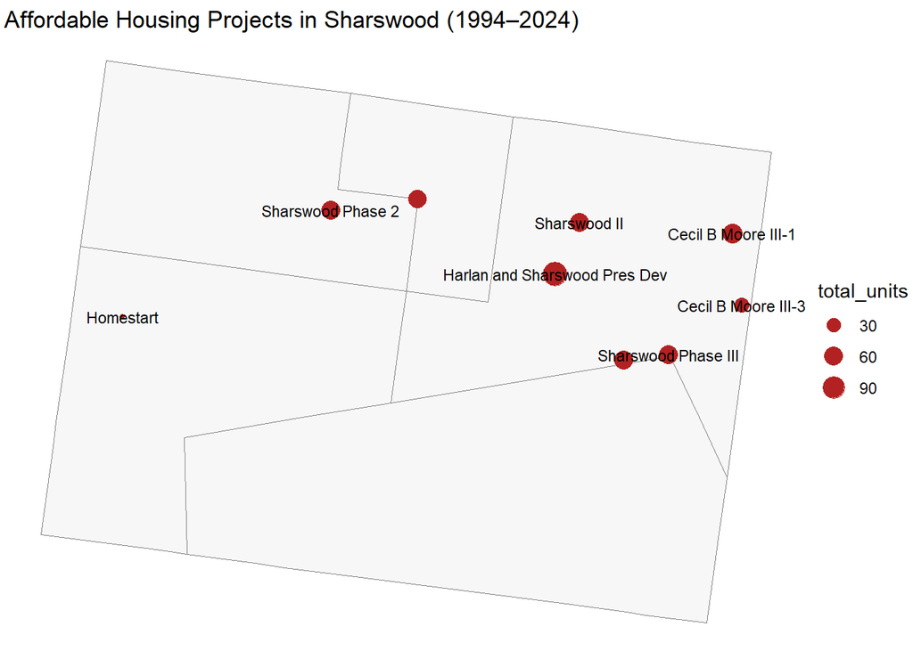

```r
ggplot() +
  geom_sf(data = sharswood_bg_sf, fill = "gray97", color = "gray50", linewidth = 0.3) +
  geom_sf(data = sharswood_affordable, aes(size = total_units),
          fill = NA, color = "firebrick", linewidth = 0.6) +
  geom_sf_text(data = sharswood_affordable, aes(label = project_name),
               size = 3, check_overlap = TRUE) +
  labs(title = "Affordable Housing Projects in Sharswood (1994–2024)") +
  theme_void()
```

**Putting it All Together**

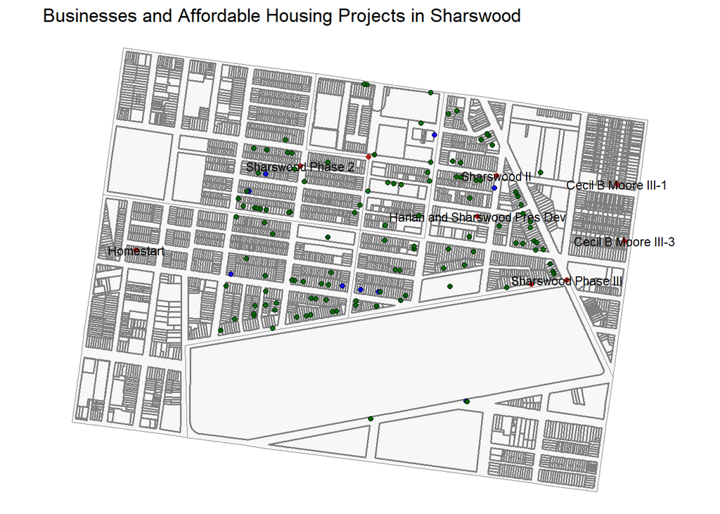

```r
ggplot() +
  geom_sf(data = sharswood_bg_sf, fill = "gray97", color = "gray50", linewidth = 0.3) +
  geom_sf(data = sharswood_parcels, fill = NA, color = "gray50", linewidth = 0.6) +
  geom_sf(data = sharswood_affordable, fill = NA, color = "firebrick", linewidth = 1) +
  geom_sf_text(data = sharswood_affordable, aes(label = project_name),
               size = 3, check_overlap = TRUE) +
  geom_sf(data = verified.sf, fill = "blue", shape = 21, size = 1.5, alpha = 0.9) +
  geom_sf(data = unverified.sf, fill = "darkgreen", shape = 21, size = 1.5, alpha = 0.9) +
  labs(title = "Businesses and Affordable Housing Projects in Sharswood") +
  theme_void()
```

**Other Datasets**

- School Parcels: https://opendataphilly.org/datasets/schools-parcels/ – parcel location of schools in the City of Philadelphia with attribute information for address, grade level, type, and status
- Schools: https://opendataphilly.org/datasets/schools/ – points identifying public schools, charter schools, many private schools, school annexes, and athletic fields and facilities

## Part 2: Comprehensive Visualization and Analysis